# Panel Data Using R - A Simple Example

## Introduction to Panel Data

Panel data, also known as longitudinal data, combines time series and cross-sectional data, providing repeated observations of multiple individuals, firms, or other units over time. This structure offers several advantages in research, particularly in addressing questions that pure cross-sectional or time series data cannot adequately answer. The significance of panel data lies in its ability to control for unobserved heterogeneity, which are individual-specific effects that are constant over time but may be correlated with the explanatory variables. By accounting for these unobserved factors, panel data analysis can reduce omitted variable bias and lead to more accurate and robust estimates of the relationships between variables.

For example, we want to understand the factor affecting the rent across multiple cities for multiple time periods, then this type of data would be ideal candidate for panel data analysis. Panel data with missing values are called ‘unbalanced Panel’ whereas panel data with no missing values are called ‘Balanced Panel’.

Panel data analysis allows us to study individual heterogeneity and allows us control for observable variables of variables that change over time.

In this article, we will be using “Rental data”. The dataset come from the publication **Introductory Econometrics: A Modern Approach, 7e** by Jeffrey M. Wooldridge, which is available as a dataset in R. The wooldridge package allows researchers to easily load any data set from the text. The package contains full documentation for each set and all data have been compressed. To load, just install the package, load it, and call the data you wish to work with. It is always recommended that one reads the supporting documentation for data sets of interest.

The objective of this exercise, is to understand the features that impact our dependent variable, (rent). Specifically, we are interested in understanding if one of the features, (student population) is a significant factor for rent.

## Data Exploration and Preparation

We load the data and do some initial exploration to understand the characteristics of the data.

```r
RENTAL<-read.csv("rentaldata.csv")
head(RENTAL)
```

```
  city year    pop enroll rent rnthsg tothsg avginc   lenroll     lpop    lrent
1    1   80  75211  15303  197  13475  26167  11537  9.635804 11.22805 5.283204
2    1   90  77759  18017  342  15660  29467  19568  9.799071 11.26137 5.834811
3    2   80 106743  22462  323  14580  37277  19841 10.019580 11.57818 5.777652
4    2   90 141865  29769  496  26895  55540  31885 10.301223 11.86263 6.206576
5    3   80  36608  11847  216   7026  13482  11455  9.379830 10.50802 5.375278
6    3   90  42099  10265  351   9557  16894  21202  9.236495 10.64778 5.860786
    ltothsg   lrnthsg   lavginc  clenroll      clpop    clrent  cltothsg
1 10.172255  9.508592  9.353314        NA         NA        NA        NA
2 10.291026  9.658865  9.881651 -15293.20 0.03331661 0.5516071 0.1187716
3 10.526132  9.587406  9.895506        NA         NA        NA        NA
4 10.924859 10.199696 10.369891 -22451.70 0.28445149 0.4289236 0.3987274
5  9.509110  8.857373  9.346182        NA         NA        NA        NA
6  9.734714  9.165030  9.961851 -11837.76 0.13975716 0.4855080 0.2256031
   clrnthsg  clavginc   pctstu     cpctstu y90
1        NA        NA 20.34676          NA   0
2 0.1502733 0.5283365 23.17031  2.82355118   1
3        NA        NA 21.04307          NA   0
4 0.6122894 0.4743853 20.98403 -0.05903244   1
5        NA        NA 32.36178          NA   0
6 0.3076563 0.6156692 24.38300 -7.97877693   1
```

You will observe that there are several variables in the RENTAL dataset. The data set is panel data as it contains a combination of cross-sectional and time data.

It contains a city for cross section and year for time series. So, lets use these features as index and create a new dataset called rental_p. In this article, we will be focused on few selected columns to understand their relationship with dependent variables, so lets just keep the columns we need and drop the rest.

```r
rental_p<- pdata.frame(RENTAL, index = c("city", "year"))
keeps<- c("lrent", "y90", "lpop", "lavginc", "pctstu")
rental_view<- rental_p[keeps]
head(rental_view)
```

```
        lrent y90     lpop   lavginc   pctstu
1-80 5.283204   0 11.22805  9.353314 20.34676
1-90 5.834811   1 11.26137  9.881651 23.17031
2-80 5.777652   0 11.57818  9.895506 21.04307
2-90 6.206576   1 11.86263 10.369891 20.98403
3-80 5.375278   0 10.50802  9.346182 32.36178
3-90 5.860786   1 10.64778  9.961851 24.38300
```

This dataset has rent related information of 64 different cities across 2 different years. The years have been labelled as either 80 or 90.

lrent refers to log of rent, which is our dependent variable, y90 refers to if the year is 90 or 80. Its 1 if year is 90 if not 0. Similarly, lavginc refers to log of average income, pctstu refers to percent of population students.

```r
summary(rental_view)
```

```
     lrent            y90           lpop          lavginc
 Min.   :5.226   Min.   :0.0   Min.   :10.16   Min.   : 9.134
 1st Qu.:5.453   1st Qu.:0.0   1st Qu.:10.62   1st Qu.: 9.511
 Median :5.781   Median :0.5   Median :11.04   Median : 9.765
 Mean   :5.746   Mean   :0.5   Mean   :11.11   Mean   : 9.788
 3rd Qu.:5.995   3rd Qu.:1.0   3rd Qu.:11.53   3rd Qu.:10.052
 Max.   :6.830   Max.   :1.0   Max.   :13.36   Max.   :10.939
     pctstu
 Min.   : 9.941
 1st Qu.:16.983
 Median :23.629
 Mean   :27.415
 3rd Qu.:35.541
 Max.   :71.210
```

## Modelling

In this article, I will explore three models, namely the OLS, the Fixed Effect and the Random Effects Model. Each model has its own purpose and is suited for a different type of panel data.

### OLS Model

OLS or the ordinary least square model. It is also termed as the pooled models. This is a Linear Regression model, which ignores the panel structure. It is efficient when the error terms in the model are homoscedastic and not autocorrelated.

```r
ols<- lm(lrent ~ y90+lpop+lavginc+pctstu, data= RENTAL)
summary(ols)
```

```
Call:
lm(formula = lrent ~ y90 + lpop + lavginc + pctstu, data = RENTAL)

Residuals:
     Min       1Q   Median       3Q      Max
-0.24233 -0.07824 -0.01642  0.04389  0.48082

Coefficients:
             Estimate Std. Error t value Pr(>|t|)
(Intercept) -0.568807   0.534881  -1.063   0.2897
y90          0.262227   0.034763   7.543 8.78e-12 ***
lpop         0.040686   0.022515   1.807   0.0732 .
lavginc      0.571446   0.053098  10.762  < 2e-16 ***
pctstu       0.005044   0.001019   4.949 2.40e-06 ***
---
Signif. codes:  0 '***' 0.001 '**' 0.01 '*' 0.05 '.' 0.1 ' ' 1

Residual standard error: 0.1259 on 123 degrees of freedom
Multiple R-squared:  0.8613,    Adjusted R-squared:  0.8568
F-statistic: 190.9 on 4 and 123 DF,  p-value: < 2.2e-16
```

Since the OLS ignores panel structure, we used the original rental data. The model shows that apart from the log of population, all other variables are significant for this model, and the model itself is significant.

### Pooled OLS MODEL using plm package

The ‘plm’ package is especially used for panel data analysis. Let’s index the data for this model as we are using the origal dataset. The results below shows that both models produce same results.

```r
pooled<- plm(lrent~y90+lpop+lavginc+pctstu,
             data= RENTAL,
             model = 'pooling',
             index = c("city", "year"))
summary(pooled)
```

```
Pooling Model

Call:
plm(formula = lrent ~ y90 + lpop + lavginc + pctstu, data = RENTAL,
    model = "pooling", index = c("city", "year"))

Balanced Panel: n = 64, T = 2, N = 128

Residuals:
     Min.   1st Qu.    Median   3rd Qu.      Max.
-0.242332 -0.078236 -0.016416  0.043890  0.480817

Coefficients:
              Estimate Std. Error t-value  Pr(>|t|)
(Intercept) -0.5688069  0.5348808 -1.0634    0.2897
y90          0.2622267  0.0347632  7.5432 8.781e-12 ***
lpop         0.0406863  0.0225154  1.8070    0.0732 .
lavginc      0.5714461  0.0530981 10.7621 < 2.2e-16 ***
pctstu       0.0050436  0.0010192  4.9486 2.401e-06 ***
---
Signif. codes:  0 '***' 0.001 '**' 0.01 '*' 0.05 '.' 0.1 ' ' 1

Total Sum of Squares:    14.058
Residual Sum of Squares: 1.9501
R-Squared:      0.86128
Adj. R-Squared: 0.85677
F-statistic: 190.922 on 4 and 123 DF, p-value: < 2.22e-16
```

To tidy up the results we use the `stargazer` package, The `Stargazer` package is a great way to create tables to neatly represent your regression outputs. The package gives options to output tables in multiple formats: .txt, LaTex code, and as .html.

```r
stargazer(pooled,
          type = "text",
          digits = 2)
```

```
========================================
                 Dependent variable:
             ---------------------------
                        lrent
----------------------------------------
y90                    0.26***
                       (0.03)

lpop                    0.04*
                       (0.02)

lavginc                0.57***
                       (0.05)

pctstu                 0.01***
                       (0.001)

Constant                -0.57
                       (0.53)

----------------------------------------
Observations             128
R2                      0.86
Adjusted R2             0.86
F Statistic    190.92*** (df = 4; 123)
========================================
Note:        *p<0.1; **p<0.05; ***p<0.01
```

### Diagnostics - Homoscedasticity Assumption (OLS Model)

Heteroscedasticity assumes variability in the observations of the dependent variable. It is just the opposite of homoscedasticity. First, we will fetch the residuals and fitted values from our OLS model. Let’s take percentage of students against the residuals to have a look at the relationship of the model.

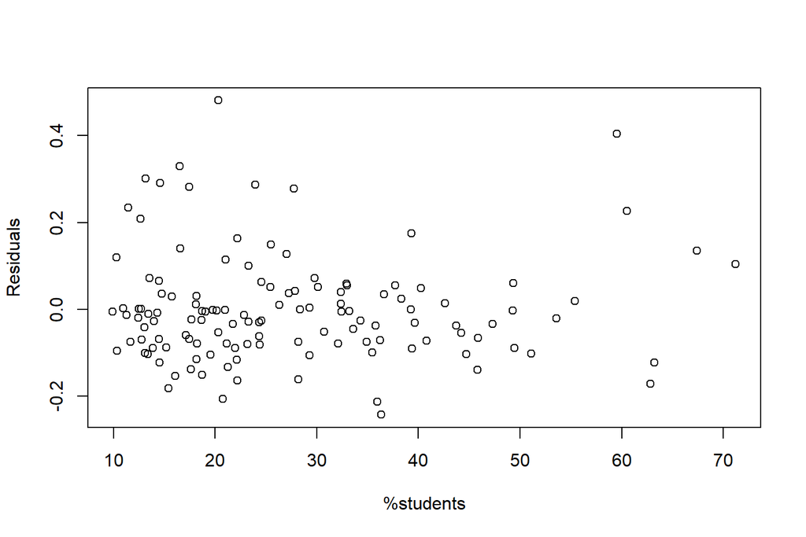

```r
res<- residuals(ols)
yhat<- fitted(ols)

plot(RENTAL$pctstu, res,
     xlab="%students",
     ylab= "Residuals")
```

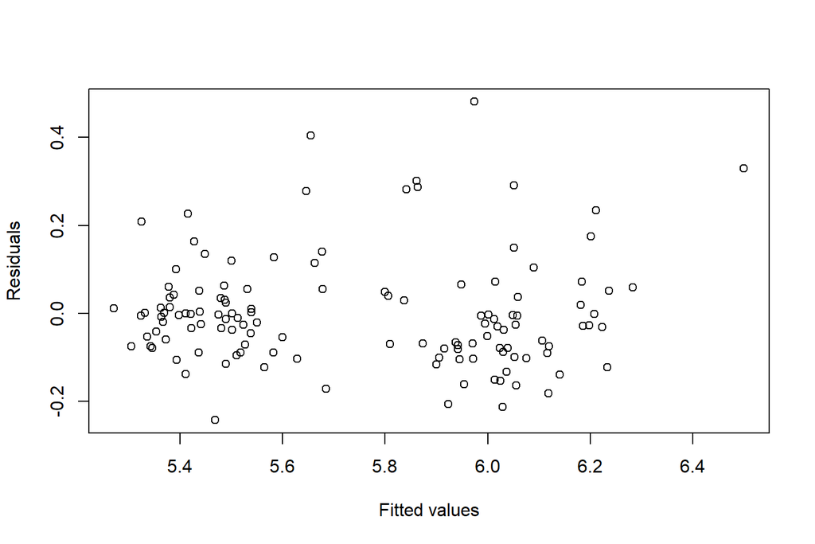

```r
plot(yhat, res,
     xlab="Fitted values",
     ylab= "Residuals")
```

We can see the spread of the data points which ensures the heteroscedastic nature as clustered patterns are visible. It just translates to the variability of the dependent variable which is the log of the rent value for our dataset. Therefore, we can conclude that OLS is not really the best model to analyze our dataset.

## The Fixed Effect Model (FE)

The Fixed Effect model assumes variations within a cross-section which could be due to the inherent characteristics of that entity, which is “city” in this example. We control for the time invariant characteristics and study the net effect of the predictors in the outcome or rent variable for this dataset. The difference between the fixed effects and the OLS model is changing this model parameter from ‘pooling’ to ‘within.’

```r
fe<- plm(lrent~y90+lpop+lavginc+pctstu,
         data= rental_p,
         model = 'within')
summary(fe)
```

```
Oneway (individual) effect Within Model

Call:
plm(formula = lrent ~ y90 + lpop + lavginc + pctstu, data = rental_p,
    model = "within")

Balanced Panel: n = 64, T = 2, N = 128

Residuals:
       Min.     1st Qu.      Median     3rd Qu.        Max.
-1.1891e-01 -2.9559e-02 -2.6541e-16  2.9559e-02  1.1891e-01

Coefficients:
         Estimate Std. Error t-value  Pr(>|t|)
y90     0.3855214  0.0368245 10.4692 3.661e-15 ***
lpop    0.0722456  0.0883426  0.8178  0.416714
lavginc 0.3099605  0.0664771  4.6627 1.788e-05 ***
pctstu  0.0112033  0.0041319  2.7114  0.008726 **
---
Signif. codes:  0 '***' 0.001 '**' 0.01 '*' 0.05 '.' 0.1 ' ' 1

Total Sum of Squares:    10.383
Residual Sum of Squares: 0.24368
R-Squared:      0.97653
Adj. R-Squared: 0.95032
F-statistic: 624.146 on 4 and 60 DF, p-value: < 2.22e-16
```

The model outcome is significant, but the log of the population remains insignificant for this relation, as it was in the OLS model. If we want to check the fixed effects for each city, we can use the fixef function to pull the values. So, to summarize, we have the fixed effects model with two out of four independent variables significant at 0.001 level and one more at 0.01 level or 1% level. Now we have to test whether fixed effects are better than OLS for this case.

```r
fixef(fe)
```

```
     1      2      3      4      5      6      7      8      9     10     11
1.3291 1.5764 1.3508 1.5104 2.0200 1.7452 1.5547 1.4304 1.7166 1.3605 1.4168
    12     13     14     15     16     17     18     19     20     21     22
1.2434 1.3610 1.8276 1.1741 1.2993 1.2189 1.2852 1.3614 1.3926 1.3678 1.4128
    23     24     25     26     27     28     29     30     31     32     33
1.5222 1.0724 1.4204 1.5026 1.4565 1.3359 1.3049 1.3567 1.4710 1.2950 1.5576
    34     35     36     37     38     39     40     41     42     43     44
1.4643 1.3513 1.5254 1.5311 1.4736 1.4049 1.3777 1.2134 1.3387 1.3639 1.2156
    45     46     47     48     49     50     51     52     53     54     55
1.3123 1.4841 1.3854 1.2142 1.4046 1.3605 1.4618 1.3730 1.4329 1.3315 1.4409
    56     57     58     59     60     61     62     63     64
1.2729 1.1004 1.5771 1.6514 1.4317 1.2471 1.3980 1.4062 1.4043
```

### Tests to Determine Superiority of FE Model over OLS

Here, the null hypothesis is OLS is better than FE model. If it is rejected at alpha of 0.05, we can proceed with the Fixed Effects model.

```r
pFtest(fe, ols)
```

```
    F test for individual effects

data:  lrent ~ y90 + lpop + lavginc + pctstu
F = 6.6693, df1 = 63, df2 = 60, p-value = 2.633e-12
alternative hypothesis: significant effects
```

We can see the p-value is much smaller than 5% level. Therefore, we can reject the null hypothesis and proceed with fixed effects model. Using `stargazer`, we tidy up the results

```r
stargazer(fe,
          type= "text",
          digits = 2)
```

```
========================================
                 Dependent variable:
             ---------------------------
                        lrent
----------------------------------------
y90                    0.39***
                       (0.04)

lpop                    0.07
                       (0.09)

lavginc                0.31***
                       (0.07)

pctstu                 0.01***
                       (0.004)

----------------------------------------
Observations             128
R2                      0.98
Adjusted R2             0.95
F Statistic    624.15*** (df = 4; 60)
========================================
Note:        *p<0.1; **p<0.05; ***p<0.01
```

Now, let’s look into the random effects model and check whether that fits our data better.

## Random Effects Model

The random effects model includes the possibility of between entity variations. It also assumes that this variation is random in nature or they are uncorrelated with variables under study.

```r
re<- plm(lrent~y90+lpop+lavginc+pctstu,
         data= rental_p,
         model = 'random')
summary(re)
```

```
Oneway (individual) effect Random Effect Model
   (Swamy-Arora's transformation)

Call:
plm(formula = lrent ~ y90 + lpop + lavginc + pctstu, data = rental_p,
    model = "random")

Balanced Panel: n = 64, T = 2, N = 128

Effects:
                   var  std.dev share
idiosyncratic 0.004061 0.063729 0.261
individual    0.011473 0.107111 0.739
theta: 0.6122

Residuals:
      Min.    1st Qu.     Median    3rd Qu.       Max.
-0.1410069 -0.0465301 -0.0039479  0.0272638  0.2718912

Coefficients:
             Estimate Std. Error z-value  Pr(>|z|)
(Intercept) 0.4451206  0.5663047  0.7860   0.43186
y90         0.3233674  0.0286635 11.2815 < 2.2e-16 ***
lpop        0.0561725  0.0287667  1.9527   0.05086 .
lavginc     0.4468825  0.0518014  8.6268 < 2.2e-16 ***
pctstu      0.0051397  0.0013049  3.9387 8.192e-05 ***
---
Signif. codes:  0 '***' 0.001 '**' 0.01 '*' 0.05 '.' 0.1 ' ' 1

Total Sum of Squares:    10.936
Residual Sum of Squares: 0.53703
R-Squared:      0.95089
Adj. R-Squared: 0.9493
Chisq: 2381.71 on 4 DF, p-value: < 2.22e-16
```

We can see that the intercept is not significant. Again, we reproduce results in a tidy format.

```r
stargazer(re,
          type= "text",
          digits = 2)
```

```
========================================
                 Dependent variable:
             ---------------------------
                        lrent
----------------------------------------
y90                    0.32***
                       (0.03)

lpop                    0.06*
                       (0.03)

lavginc                0.45***
                       (0.05)

pctstu                 0.01***
                       (0.001)

Constant                0.45
                       (0.57)

----------------------------------------
Observations             128
R2                      0.95
Adjusted R2             0.95
F Statistic          2,381.71***
========================================
Note:        *p<0.1; **p<0.05; ***p<0.01
```

As the overall model is significant, we proceed to the diagnostic tests to determine how the Random Effects model fares over the other models. We have already concluded that fixed effects model is better than the OLS model. So now we will compare between fixed effects and random effects model. We will use a very popular diagnostic test for this purpose called Hausman Test. The null hypothesis of this test states that random effects is preferred over fixed effects.

```r
phtest(fe, re)
```

```
    Hausman Test

data:  lrent ~ y90 + lpop + lavginc + pctstu
chisq = 13.272, df = 4, p-value = 0.01002
alternative hypothesis: one model is inconsistent
```

The p-value here is less than 0.05 Therefore, we can reject the null hypothesis and conclude that the fixed effects model is more suited to rental data.

## Compare Results of Models

To do this, we use the `stargazer` package again.

```r
stargazer(pooled, fe, re,
          type = "text",
          digits = 2,
          header = FALSE,
          title= "Regression Results",
          covariate.labels = c("Year1990", "log(population)", "Avg Income", "Student Pop"),
          dep.var.caption  = "Dependent Variable",
          column.labels   = c("Pooled", "FE","RE"),
          column.separate = c(1, 1, 1))
```

```
Regression Results
==========================================================================
                                    Dependent Variable
                ----------------------------------------------------------
                                          lrent
                        Pooled                    FE               RE
                          (1)                    (2)               (3)
--------------------------------------------------------------------------
Year1990                0.26***                0.39***           0.32***
                        (0.03)                  (0.04)           (0.03)

log(population)          0.04*                   0.07             0.06*
                        (0.02)                  (0.09)           (0.03)

Avg Income              0.57***                0.31***           0.45***
                        (0.05)                  (0.07)           (0.05)

Student Pop             0.01***                0.01***           0.01***
                        (0.001)                (0.004)           (0.001)

Constant                 -0.57                                    0.45
                        (0.53)                                   (0.57)

--------------------------------------------------------------------------
Observations              128                    128               128
R2                       0.86                    0.98             0.95
Adjusted R2              0.86                    0.95             0.95
F Statistic     190.92*** (df = 4; 123) 624.15*** (df = 4; 60) 2,381.71***
==========================================================================
Note:                                          *p<0.1; **p<0.05; ***p<0.01
```

## Analysing the best model

Now we know that fixed effect model is the best for the data, we now analyze the relationship between independent and dependent variables from that model.

```r
summary(fe)
```

```
Oneway (individual) effect Within Model

Call:
plm(formula = lrent ~ y90 + lpop + lavginc + pctstu, data = rental_p,
    model = "within")

Balanced Panel: n = 64, T = 2, N = 128

Residuals:
       Min.     1st Qu.      Median     3rd Qu.        Max.
-1.1891e-01 -2.9559e-02 -2.6541e-16  2.9559e-02  1.1891e-01

Coefficients:
         Estimate Std. Error t-value  Pr(>|t|)
y90     0.3855214  0.0368245 10.4692 3.661e-15 ***
lpop    0.0722456  0.0883426  0.8178  0.416714
lavginc 0.3099605  0.0664771  4.6627 1.788e-05 ***
pctstu  0.0112033  0.0041319  2.7114  0.008726 **
---
Signif. codes:  0 '***' 0.001 '**' 0.01 '*' 0.05 '.' 0.1 ' ' 1

Total Sum of Squares:    10.383
Residual Sum of Squares: 0.24368
R-Squared:      0.97653
Adj. R-Squared: 0.95032
F-statistic: 624.146 on 4 and 60 DF, p-value: < 2.22e-16
```

Our initial question we wanted to answer was if the student population has any impact on a city’s rent. This model shows that the percentage of student population is significant at 1% level. In comparison, the other variables except population are significant at 0.1% level. The coefficients of the independent variables indicate how much the dependent variable changes over time on average per city, when the independent variables increase by one unit. The independent variables here can explain the dependent variable satisfactory. And this can be further validated by adjusted R-Squared of 95%

## Additional Diagnostics Tests for Panel Data

Here, I will show you few more diagnostic tests that you may require to analyze other datasets.

### Diagnostics - Existence of Panel Effects in data

The hypothesis of this test states that OLS is a better model and the alternative hypothesis suggests random effects to be a better model. Let us conduct the test on our pooled model.

```r
plmtest(pooled, type=c("bp"))
```

```
    Lagrange Multiplier Test - (Breusch-Pagan)

data:  lrent ~ y90 + lpop + lavginc + pctstu
chisq = 29.111, df = 1, p-value = 6.836e-08
alternative hypothesis: significant effects
```

Since the value is much less than 0.05 level, we can reject the null hypothesis and conclude that panel effects indeed exist in the data.

The next two tests are specifically used for macro panels with longer time series. Therefore, it is not suitable for data like this one, which has only two time periods. But for illustration purposes we also include how the diagnostic tests can be used for research and analysis.

### Diagnostics: Cross-sectional dependence

Here we will use two test one is called Breusch-Pagan LM test and the other one is called Pesaran CD test. The null hypothesis for both test is that there is no cross-sectional dependence. If the p-value is less than 0.05 we reject the null and conclude that there is cross-sectional dependence.

```r
pcdtest(fe, test=c("lm"))
```

```
    Breusch-Pagan LM test for cross-sectional dependence in panels

data:  lrent ~ y90 + lpop + lavginc + pctstu
chisq = 4032, df = 2016, p-value < 2.2e-16
alternative hypothesis: cross-sectional dependence
```

```r
pcdtest(fe, test=c("cd"))
```

```
    Pesaran CD test for cross-sectional dependence in panels

data:  lrent ~ y90 + lpop + lavginc + pctstu
z = -0.44096, p-value = 0.6592
alternative hypothesis: cross-sectional dependence
```

As i mentioned earlier, due to lack of time series, this test is not suitable to infer anything about the cross-sectional dependence for this data.

### Diagnostics: Test for serial correlation

The null hypothesis for this test is that there is no serial correlation. We reject the null if the p-value is less than 0.05 and conclude that serial correlation exists.

```r
pbgtest(fe)
```

```
    Breusch-Godfrey/Wooldridge test for serial correlation in panel models

data:  lrent ~ y90 + lpop + lavginc + pctstu
chisq = 49.685, df = 2, p-value = 1.626e-11
alternative hypothesis: serial correlation in idiosyncratic errors
```

So following the earlier reasons as above, this test is not suitable for the rental dataset.

### Diagnostics: Test for Heteroscedasticity

Since, I wanted to illustrate the effect of heteroscedasticity graphically, I did not include this test earlier along with the pooled model.

```r
bptest(lrent~y90+lpop+lavginc+pctstu+factor(city),
       data= rental_p,
       studentize = F)
```

```
    Breusch-Pagan test

data:  lrent ~ y90 + lpop + lavginc + pctstu + factor(city)
BP = 123.81, df = 67, p-value = 3.005e-05
```

The null hypothesis assumes homoscedasticity in the data. However, the result has a p-value less than 0.05 which allows us to reject the null and it conforms the initial visual analysis that heteroscedasticity exists in this data set.

## References

1. Hlavac, Marek (2022). stargazer: Well-Formatted Regression and Summary Statistics Tables.